# Language Models for Information Retrieval

Team 4 · Topic 2 · Query likelihood and smoothing

Team 4

November 3, 2026

## The search problem

A user types **“language model probability.”**

Our collection contains documents about unigrams, query likelihood, bigrams, and perplexity.

How can we rank the documents using the probability of the query?

## The query likelihood idea

1. Estimate a language model for each document.
2. Calculate how likely that model is to generate the query.
3. Rank documents by that likelihood.

**Input:** a query and a document collection.  
**Output:** documents ordered by score.

## Connection to Lecture 2

| Lecture 2 | Our retrieval model |
| --- | --- |
| Bag-of-words | Count terms in each document |
| N-gram probability | Estimate the probability of query text |
| Log probabilities | Add log scores for numerical stability |
| Unseen events and smoothing | Give partial matches a usable score |

**Our choice:** a unigram model, so word order is ignored.

Course lecture: slides 4–8 and 12–20.

## Earlier retrieval methods

| Method | How it matches | Main gap |
| --- | --- | --- |
| Boolean AND | Every required term must appear | Partial matches are rejected |
| TF-IDF cosine | Similarity of weighted term vectors | Depends on exact vocabulary |
| Query likelihood | Probability under each document model | Needs reliable probability estimates |

Ponte and Croft introduced a language modeling approach to IR in **1998**.

## Scoring a document

$$P_{\mathrm{MLE}}(w\mid d)=\frac{c(w,d)}{|d|}$$

$$s(d,q)=\sum_{w\in q}c(w,q)\log P(w\mid d)$$

- $c(w,d)$ counts a word in the document. $|d|$ is its token count.
- Sum over distinct query terms. Repeated terms count again.
- **Higher is better:** a log score of −4 ranks above −8.

## A missing word makes the whole product zero

Query: **“search documents”**

Document: **“language models rank documents”**

$$P_{\mathrm{MLE}}(\text{search}\mid d)=0$$

$$P(q\mid d)=0\times P(\text{documents}\mid d)=0$$

Many partial matches tie at zero. In log space, their score is $-\infty$.

## Collection-based smoothing

$$P_\mu(w\mid d)=\frac{c(w,d)+\mu P(w\mid C)}{|d|+\mu}$$

**Dirichlet:** $\mu$ controls collection-based pseudo-counts.

$$P_\lambda(w\mid d)=(1-\lambda)\frac{c(w,d)}{|d|}+\lambda P(w\mid C)$$

**Jelinek–Mercer:** $\lambda$ is a fixed **background weight** here.

$P(w\mid C)=c(w,C)/|C|$. Collection frequencies replace the uniform background used by add-one smoothing.

## A worked calculation

Collection: **14 tokens**, with `search` twice and `documents` three times.

Document C: **“language models rank documents”**, length 4. Set $\mu=5$.

$$P(\text{search}\mid C_{doc})=\frac{0+5(2/14)}{4+5}\approx0.0794$$

$$P(\text{documents}\mid C_{doc})=\frac{1+5(3/14)}{4+5}\approx0.2302$$

$$P(q\mid C_{doc})\approx0.0183,\qquad s\approx-4.003$$

## Parameters and assumptions

- We use **$\mu=20$** and **$\lambda=0.2$** in the main experiment.
- Larger $\mu$ gives more weight to collection frequencies.
- Unigrams ignore order and do not identify synonyms.
- We report and drop terms absent from the collection.

**All query terms unknown:** return no ranking.

## Experiment setup

**15 documents · 5 queries · declared binary relevance labels**

| Choice | What we do |
| --- | --- |
| Preprocessing | Lowercase alphabetic words, no stemming |
| Baseline | TF-IDF cosine similarity |
| Language models | MLE, JM (0.2), Dirichlet (20) |
| Evaluation | P@3, Recall@3, MAP, MRR |

This is a teaching collection with our own labels, not a benchmark.

## Python experiment

```python
experiment = RetrievalExperiment(documents)

for query in queries:
    ranking, unknown = experiment.rank(
        query["text"], method="dirichlet", mu=20
    )
    metrics = evaluate(ranking, query["relevant"])
    print(query["id"], ranking[:3], metrics)
```

The notebook includes the full implementation, outputs, and checks.

## Results on our collection

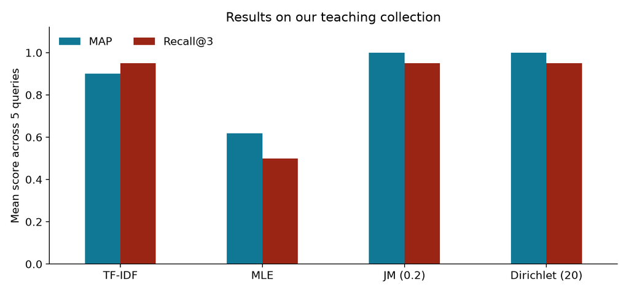

| Method | MAP | Recall@3 |
| --- | --- | --- |
| TF-IDF | 0.900 | 0.950 |
| MLE | 0.619 | 0.500 |
| JM | 1.000 | 0.950 |
| Dirichlet | 1.000 | 0.950 |

Smoothed models improve the first relevant rank on **one of five queries**.

## Why Q5 changes rank

Query: **“car coverage”** · Intended need: vehicle insurance

| Method | First result | Second result |
| --- | --- | --- |
| TF-IDF | D14: car parking | D13: automobile insurance |
| Dirichlet | D13: automobile insurance | D14: car parking |

D14 repeats `car`. D13 contains `coverage`, but uses `automobile`.

**What we learned:** smoothing preserves useful partial evidence. It did not learn that `car` and `automobile` are synonyms.

## Sensitivity to smoothing

| $\mu$ | MAP | Recall@3 |
| --- | --- | --- |
| 0.1 | 1.000 | 0.950 |
| 1 | 1.000 | 0.950 |
| 5 | 1.000 | 0.950 |
| 20 | 1.000 | 0.950 |
| 100 | 1.000 | 0.950 |
| 1000 | 1.000 | 0.950 |

We vary $\mu$ on the same five queries. This is **sensitivity analysis**, not held-out tuning.

For a real study, choose parameters on development queries and report results on separate test queries.

## Limitations and comparison

| Limitation | Consequence or next step |
| --- | --- |
| Exact vocabulary | `car protection` still favors parking |
| Word order ignored | Unigrams cannot distinguish reordered words |
| Parameter choice | Tune smoothing on development queries |
| Tiny, manually judged collection | Use an independent judged benchmark |

TF-IDF is a simple baseline. BM25 adds term-frequency saturation and length normalization, but also relies mainly on lexical matching.

## A documented IR system: Indri

The **Lemur Project’s Indri** uses language modeling for retrieval.

Its documentation describes query-likelihood scoring with **Dirichlet smoothing** and returned log scores.

Its documented default is **$\mu=2500$**. That setting is not automatically suitable for our short teaching documents.

[Lemur Project: Indri Document Scoring](https://sourceforge.net/p/lemur/wiki/Indri%20Document%20Scoring/)

## Conclusion and next steps

Query likelihood ranks documents by how likely their word distributions are to generate the query.

Smoothing makes partial matches usable. Our experiment shows a benefit on one query and a remaining vocabulary failure.

**Next step:** evaluate on a judged benchmark, tune on development queries, and compare BM25 and query expansion.

## References

- DORN Dawin (2026). *Lecture 2: NLP Foundations I: Bag-of-Words and Language Models*. ITC, slides 4–8, 12–20.
- *Group Discussion Topics: Retrieval Models*. Supplied handout, pp. 1 and 3.
- Manning, Raghavan & Schütze (2008). *Introduction to Information Retrieval*, [Chapter 12](https://nlp.stanford.edu/IR-book/pdf/12lmodel.pdf).
- Ponte & Croft (1998). *A Language Modeling Approach to Information Retrieval*. [SIGIR paper](https://ciir.cs.umass.edu/pubfiles/ir-120.pdf).
- Zhai & Lafferty (2001). *A Study of Smoothing Methods for Language Models Applied to Ad Hoc Information Retrieval*. [SIGIR paper](https://www.cs.cmu.edu/~czhai/paper/sigir2001-smooth.pdf).
- Lemur Project. [Indri scoring](https://sourceforge.net/p/lemur/wiki/Indri%20Document%20Scoring/) and [query language](https://www.lemurproject.org/lemur/IndriQueryLanguage.php).
- Scikit-learn. [TfidfVectorizer API](https://scikit-learn.org/stable/modules/generated/sklearn.feature_extraction.text.TfidfVectorizer.html).